# Deep learning

Szabo Roland

- branch of machine learning
  - based mostly on neural networks
- first proposed in 1980 by Kunihiko Fukushima
- got popular after 2006 when Geoffrey Hinton presented a faster way of training them
- used to get the current state of the art in object recognition in images, speech recognition and sentiment analysis
- big companies research it and use it in everyday technology:
  - Microsoft - speech recognition, machine translation, image search
  - Google - Google Now, auto-tagging posts and images in G+
  - Apple - Siri
  - Facebook - probably for ads :)
  - Netflix - movie recomandations

# Difference from other ML algorithms

| Deep learning | Other algorithms |
| --- | --- |
| learns $f_1(f_2(f_3(...(x)))) = y$ | learn a function f(x) = y |
| automatic feature extraction | features have to be developed by hand |
| uses lots of unlabeled data in addition to labeled data | usually uses only unlabeled data or only labeled data |

# Meet Sel (Single eyed learner)

[figure not shown]

## Sel's brain

[figure not shown]

- Sel lives in a very simple world
- he either
  - sleeps
  - is awake and sees with his eye
- what he sees is one of the following, with a certain probability $p_0$:

[figure not shown]

- while sleeping, his brain is trying to learn the probability of seeing either of the images and projects with the learned probability $p_s$ one of the images to his eye (like a dream)
- if Sel's brain can learn $p_s = p_0$, then Sel is as intelligent as he can get
  - he knows all about his world
  - he can't tell the difference between dreaming and reality **cue Inception music**

# Meet Sel's grand-grand-grandson

[figure not shown]

- has eye, ear, hands, feet
- and a suitably more complex brain
- instead of just one neuron/input, it has two: one for the current input and one for expected input

[figure not shown]

# Classic neural networks

[figure not shown]

- made of layers, which are themselves made of neurons
- neurons make a local decision to fire or not based on incoming values
- the values are propagated from input to output
- learning using backpropagation
  - the error is going backwards - from output to input

```python
import numpy as np
from numpy.random import random as rand

class NeuralNetwork:

    activations = {
        'tanh': lambda x: np.tanh(x),
        'relu': lambda x: np.clip(x, 0, np.max(x))
    }
    derivatives = {
        'tanh': lambda x: 1.0 - x**2,
        'relu': lambda x: (np.sign(x) + 1)*0.5
    }

    def __init__(self, layers, activation='tanh', learning_rate=0.2, reg=0.0001,
                 epochs=10000):
        self.activation = NeuralNetwork.activations[activation]
        self.activation_deriv = NeuralNetwork.derivatives[activation]
        self.learning_rate, self.epochs, self.reg = learning_rate, epochs, reg

        self.initialize_weights(layers)

    def initialize_weights(self, layers):
        self.weights = []
        for i in range(1, len(layers) - 1):
            self.weights.append((2*rand((layers[i-1]+1, layers[i] + 1))-1)*0.25)
        self.weights.append((2*rand((layers[i] + 1, layers[i + 1]))-1)*0.25)

    def regularize(self, weights):
        return self.reg * np.sum(weights)
```

```python
    def fit(self, X, y):
        X = np.atleast_2d(X)
        X = np.hstack((X, np.ones([1, X.shape[0]]).T))
        y = np.array(y)

        for k in range(self.epochs):
            i = np.random.randint(X.shape[0])
            a = [np.atleast_2d(X[i])]

            for l in range(len(self.weights)):
                    a.append(self.activation(np.dot(a[l], self.weights[l])))
            deltas = [(y[i] - a[-1]) * self.activation_deriv(a[-1])]

            for l in range(len(a) - 2, 0, -1): # begin at the second to last layer
                deltas.append(deltas[-1].dot(self.weights[l].T)*
                              self.activation_deriv(a[l]))
            deltas.reverse()
            for i in range(len(self.weights)):
                self.weights[i] += self.learning_rate * (
                    a[i].T.dot(deltas[i]) - self.regularize(self.weights[i])
                )

    def predict(self, X):
        X = np.append(X, 0)
        for l in range(0, len(self.weights)):
            X = self.activation(np.dot(X, self.weights[l]))
        return X
```

# What changes in deep learning?

## Initialization

Instead of randomly choosing weights, pretrain using unlabeled data

### Restricted Boltzmann Machines

[figure not shown]

- a stochastic generative neural networks
- undirected (information can flow both ways)
- learn latent factors that explain input

### Autoencoders

[figure not shown]

- tries to reproduce its input, but using a different number of feature
- learns to compress or remove noise from input

## Better, more specific regularization

- normal regularization: L1 ($\sum_i w_i$) or L2 ($\sum_i w_i^2$)

[figure not shown]

- dropout

## New kinds of layers

[figure not shown]

- convolution layers (not so new)
- maxpooling layers

[figure not shown]

- rectified linear layers
- maxout layers

# The math

Softmax regression:

$p(y \mid x) = \frac { \exp( x^T W + b ) } { \sum_i \exp(x^T W + b)_i } = \text{softmax}( x^T W + b)$

Multilayer perceptron:

$f(x) = \text{softmax}( \sigma ( x^T W^{(1)} + b^{(1)} )^T W^{(2)} + b^{(2)})$

Restricted Boltzmann Machines:

$- \frac{\partial{ \log p(v)}}{\partial W_{ij}} = E_v[p(h_i|v) \cdot v_j] - v^{(i)}_j \cdot sigm(W_i \cdot v^{(i)} + c_i)$

Convolution operator:

$o[m,n] = f[m,n]*g[m,n] = \sum_{u=-\infty}^{\infty} \sum_{v=-\infty}^{\infty} f[u,v] g[u-m,v-n]$

Cross-entropy for autoencoders:

$L_{H} (\mathbf{x}, \mathbf{z}) = - \sum^d_{k=1}[\mathbf{x}_k \log \mathbf{z}_k + (1 - \mathbf{x}_k)\log(1 - \mathbf{z}_k)]$

- luckily, we only need to know all this if we want to create a new, better model
- all of these improvements are already implemented in various libraries

# [scikit-learn](http://scikit-learn.org)

- one of the best ML libraries
- a bit short on the deep learning side
- has only RBMs
  - but MLP are probably going to be part of the next release
  - autoencoders are a work in progress
- really user-friendly: same API for all algorithms
- has very good preprocessing utilities

```python
from sklearn.neural_network import BernoulliRBM as RBM
import numpy as np
import matplotlib.pyplot as plt
import cPickle
from time import time
```

```
Size: 6562 400
Starting RBM fitting
('Time: %d', 110.1371910572052)
```

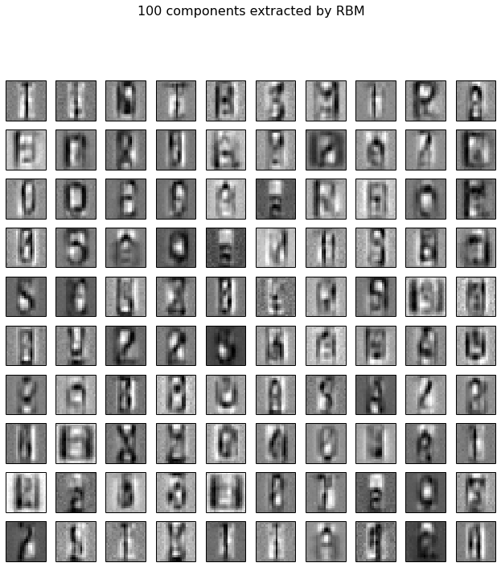

```python
X,y = cPickle.load(open("files/my_letters.pkl"))
print("Size: %d %d" % X.shape)
X = (X - np.min(X, 0)) / (np.max(X, 0) + 0.0001)  # 0-1 scaling
rbm = RBM(n_components=400, learning_rate=0.05, batch_size=100, n_iter=50)
print("Starting RBM fitting")
t = time()
rbm.fit(X)
print("Time: %d", time()-t)
plt.figure(figsize=(10.2, 10))
for i, comp in enumerate(rbm.components_):
    if i > 99:
        break
    plt.subplot(10, 10, i + 1)
    plt.imshow(comp.reshape((20, 20)), cmap=plt.cm.gray_r,
               interpolation='nearest')
    plt.xticks(())
    plt.yticks(())
plt.suptitle('100 components extracted by RBM', fontsize=16)
plt.subplots_adjust(0.08, 0.02, 0.92, 0.85, 0.08, 0.23)

plt.show()
```

# [Pylearn2](http://deeplearning.net/software/pylearn2/)

- research oriented library
  - all the latest algorithms
  - but you have to do some hacks to use it for predictions
- they like YAML for some reason

```python
from __future__ import division
from pylearn2.train import Train
from pylearn2.datasets.mnist import MNIST
from pylearn2.models import softmax_regression, mlp
from pylearn2.training_algorithms import bgd
from pylearn2.termination_criteria import MonitorBased
from pylearn2.train_extensions import best_params
from pylearn2.utils import serial
from theano import function
from theano import tensor as T
import numpy as np
import os
```

```python
h0 = mlp.Sigmoid(layer_name='h0', dim=500, sparse_init=15)
ylayer = mlp.Softmax(layer_name='y', n_classes=10, irange=0)
layers = [h0, ylayer]

model = mlp.MLP(layers, nvis=784)
train = MNIST('train', one_hot=1, start=0, stop=50000)
valid = MNIST('train', one_hot=1, start=50000, stop=60000)
test = MNIST('test', one_hot=1, start=0, stop=10000)

monitoring = dict(valid=valid)
termination = MonitorBased(channel_name="valid_y_misclass")
extensions = [best_params.MonitorBasedSaveBest(channel_name="valid_y_misclass",
    save_path="train_best.pkl")]
algorithm = bgd.BGD(batch_size=10000, line_search_mode = 'exhaustive', conjugate = 1,
        monitoring_dataset = monitoring, termination_criterion = termination)

save_path = "train_best.pkl"
if os.path.exists(save_path):
    model = serial.load(save_path)
else:
    print 'Running training'
    train_job = Train(train, model, algorithm, extensions=extensions, save_path="train.pkl", save_freq=1)
    train_job.main_loop()

X = model.get_input_space().make_batch_theano()
Y = model.fprop(X)

y = T.argmax(Y, axis=1)
f = function([X], y)
yhat = f(test.X)

y = np.where(test.get_targets())[1]

print 'accuracy', (y==yhat).sum() / y.size
```

```
CPU times: user 0 ns, sys: 0 ns, total: 0 ns
Wall time: 9.06 µs
Running training
```

```
compiling begin_record_entry...
```

[output not shown]

[output cut: 25 more lines]

[output not shown]

[output not shown]

[output cut: 1543 more lines]

```
	valid_y_col_norms_mean: 10.0484342325
	valid_y_col_norms_min: 7.90382518355
	valid_y_max_max_class: 0.999999998676
	valid_y_mean_max_class: 0.983579766541
	valid_y_min_max_class: 0.334148418478
	valid_y_misclass: 0.0203
	valid_y_nll: 0.0687193013942
	valid_y_row_norms_max: 4.18156614444
	valid_y_row_norms_mean: 1.28410675272
	valid_y_row_norms_min: 0.191241730146
Saving to train.pkl...
Saving to train.pkl done. Time elapsed: 0.464336 seconds
Saving to train.pkl...
Saving to train.pkl done. Time elapsed: 0.506982 seconds
accuracy 0.98
```

# [Overfeat](https://github.com/sermanet/OverFeat)

- not a library, but a pretrained convnet for object recognition in images
- from New York University, by professor Yann LeCunn
- can be used:
  - to classify objects with ImageNet classes
  - to extract high level features which are then fed into your own classifier

```python
%pylab inline
import cv2
import overfeat
from scipy.ndimage import imread
from scipy.misc import imresize
from IPython.core.display import Image, display

cap = cv2.VideoCapture(0)
# initialize overfeat. Note that this takes time, so do it only once if possible
overfeat.init('default/net_weight_1', 1)
```

```
WARNING: pylab import has clobbered these variables: ['imread']
`%pylab --no-import-all` prevents importing * from pylab and numpy
```

```python
def classify(img):
    image = imread(img)
    # resize and crop into a 231x231 image
    DIM = 231
    h0, w0 = image.shape[:2]
    d0 = float(min(h0, w0))
    h1 = int(round(DIM*h0/d0))
    w1 = int(round(DIM*w0/d0))
    d1 = DIM
    image = (imresize(image, (h1, w1))).astype(float32)
    image = image[int(round((h1-d1)/2.)):int(round((h1-d1)/2.)+DIM),
                  int(round((w1-d1)/2.)):int(round((w1-d1)/2.)+DIM), :]
    display(Image(filename=img, width=300))
    h,w,c = image.shape
    image = image.reshape(w*h, c)
    image = image.transpose()
    image = image.reshape(c, h, w)
    b = overfeat.fprop(image)
    b = b.flatten()
    top = [(b[i], i) for i in xrange(len(b))]
    top.sort()
    print "\nTop classes :"
    for i in xrange(5):
        print(overfeat.get_class_name(top[-(i+1)][1]))
```

```python
os.listdir('files/overfeat')
```

```
['bee.jpg',
 'cat.jpg',
 'cup.jpg',
 'dog.jpg',
 'pliers.jpg',
 'stairs.jpg',
 'watch.jpg']
```

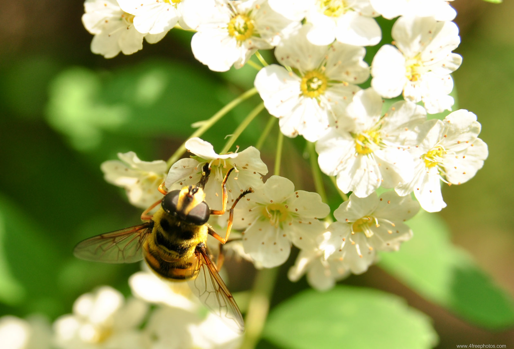

```
Top classes :
bee
fly
long-horned beetle, longicorn, longicorn beetle
leaf beetle, chrysomelid
ant, emmet, pismire
```

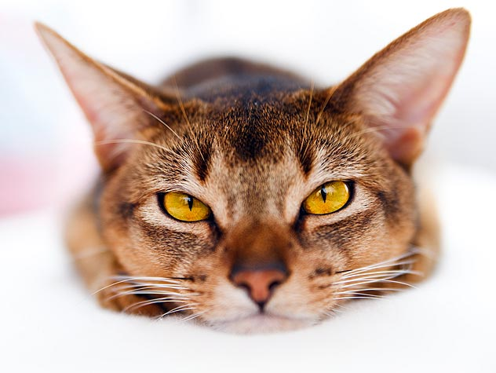

```
Top classes :
tiger cat
tabby, tabby cat
Egyptian cat
lynx, catamount
feather boa, boa
```

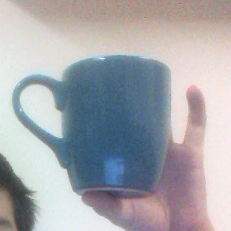

```
Top classes :
coffee mug
cup
pitcher, ewer
coffeepot
teapot
```

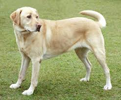

```
Top classes :
Labrador retriever
golden retriever
Saluki, gazelle hound
bloodhound, sleuthhound
redbone
```

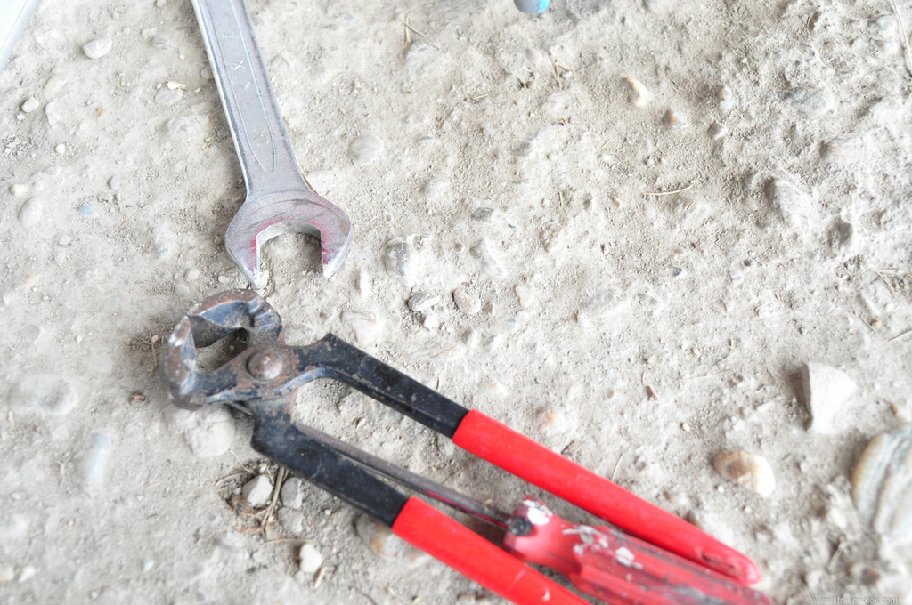

```
Top classes :
screwdriver
shovel
starfish, sea star
syringe
nail
```

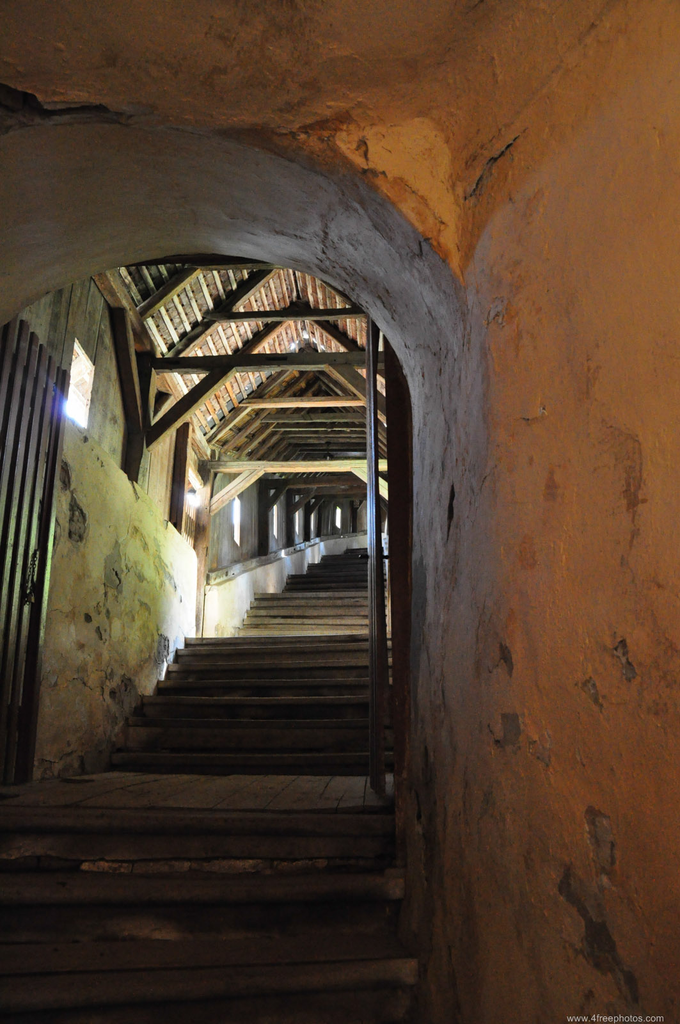

```
Top classes :
vault
organ, pipe organ
prison, prison house
monastery
palace
```

[figure not shown]

```
Top classes :
stopwatch, stop watch
digital watch
analog clock
magnetic compass
barometer
```

```python
for file in os.listdir('files/overfeat'):
    classify('files/overfeat/'+file)
```

# Plot twist

The second best result on MNIST, 0.35% errors, was obtained by Dan Ciresan et al. in 2010, using "good old backpropagation", without any pretraining, without dropout, without any special layers.

The trick?

Artficially increasing the number of input images, via elastic distortions (translations, rotations, scaling, squeezing)

Geoffrey Hinton also now recommends skipping pretraining if you have enough data (but he still uses dropout, convolutional layers and ReLu units in his DREDNets)

# Questions?

Slides on my Github: https://github.com/rolisz/presentations

More about creatures similar to Sel and how to train them on a quantum computer, over at the D-Wave blog: http://dwave.wordpress.com/2013/11/26/boltzmann-machines-distributions-of-patterns-from-the-real-world/